# Lab3

GAO Zheng

September 27, 2016

# More on plotting

This example contains a few frequently used plotting parameters:

- Line/Point styles: `type`, `lty`, `pch`, `col`, …
  - `type`: consult `?plot`, it refers to the type of the line. ‘b’ for showing both the points and the line, ‘o’ for both but over-positioning each other, ‘l’ for line-only and ‘p’ for points-only.
  - `lty`: line type, take integer values.
  - `pch`: the point marker used, take integer or character values.
  - `col`: color, take integer or character values.
- Plot range: `xlim`, `ylim`. Here we expanded the plot ranges to have more comfortable margins.
- Texts: `main`, `sub`, `xlab`, `ylab`, …
  - `main`: main title of the plot.
  - `sub`: subtitle.
  - `xlim`, `ylim`: ranges of axes.
- Font sizes: `cex` (default), `cex.main`, `cex.sub`, `cex.lab`, `cex.axis`, …
- Axes: `axes` …
- Margin: `par(mar = )` …
- Layout: `layout`, `par(mfrow = )` …

Let us improve the plot from lecture.

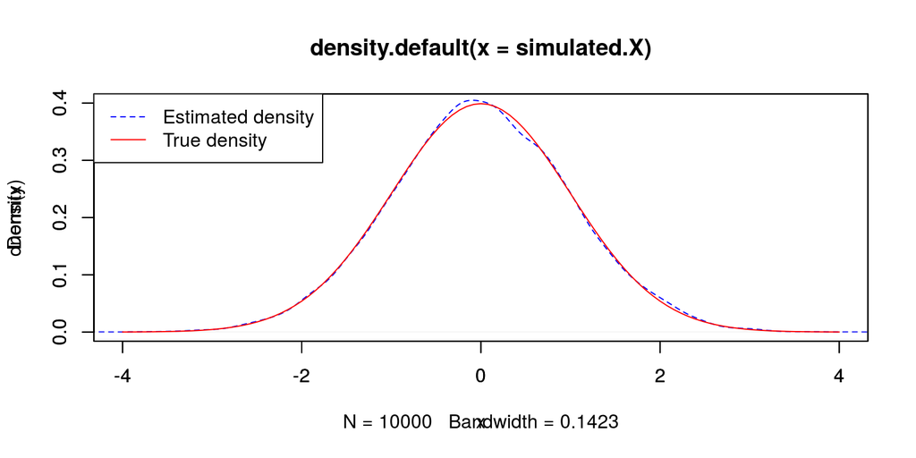

```r
simulated.X = rnorm(n=10000);
dens = density(simulated.X);
plot(dens, col = 'blue', lty = 2, xlim=c(-4,4), ylim=c(0,0.4))
par(new=T)
curve(dnorm,lty=1, col='red',xlim=c(-4,4),ylim=c(0,0.4))
legend(x='topleft',legend=c('Estimated density','True density'),
       col=c('blue','red'),lty=c(2,1))
```

Notice the overlapping axes and axes labels, we want to get rid of them.

A slightly improved plot looks like this:

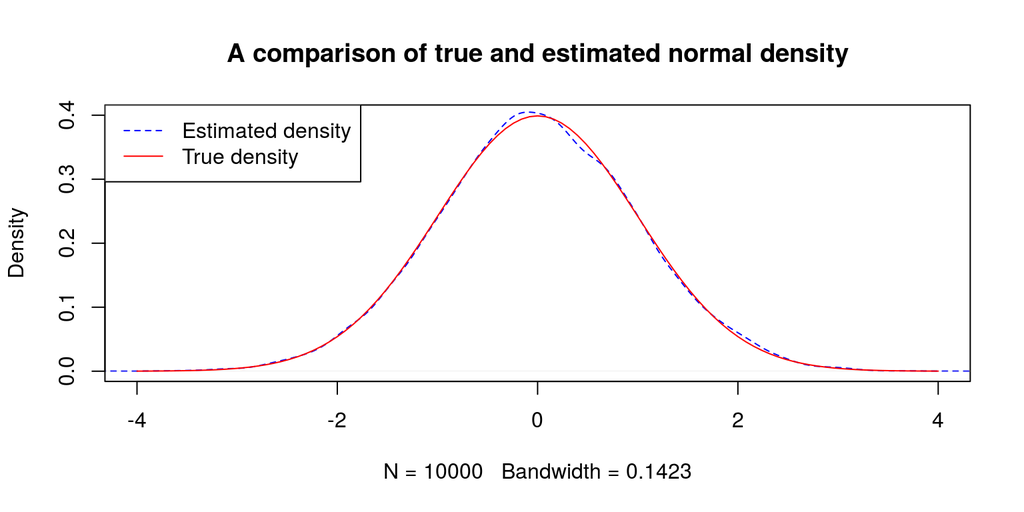

```r
plot(
  dens, col = 'blue', lty = 2, xlim = c(-4,4), ylim = c(0,0.4),
  main = "A comparison of true and estimated normal density"
)
par(new = T)
curve(
  dnorm,lty = 1, col = 'red',xlim = c(-4,4), ylim = c(0,0.4),
  axes = FALSE, xlab = "", ylab = ""
)
legend(
  x = 'topleft',legend = c('Estimated density','True density'),
  col = c('blue','red'), lty = c(2,1)
)
```

It is possible to come up with pretty plots using only base packages. Plotting needs a little practice (and some Googling).

# Data wrangling

In real life (in work), most of our time is spent wrangling with datasets; figuring out how things are recorded, dealing with missing data, extract the useful bits of information from a menagerie of variables. Much less time is spent on actual discovery and trying to draw insights from the datasets. Unfortunate, but most of the time it is the case.

Datasets in classes are mostly curated, clearly annotated. The real world is a lot messier.

The following is an example of real world dataset, still quite well-behaved, but it is closer to what datasets look like out there.

The dataset is adapted from:

[Allison, T. and Chichetti, D. (1976) Sleep in mammals: ecological and constitutional correlates. Science 194 (4266), 732–734.](http://science.sciencemag.org/content/194/4266/732)

- The dataset consists of animal sleep data with 62 observations on 10 variables.
- Some of the variables are missing.
- The dataset is splitted into two (deliberately): First contains the observation ID plus the first 6 variables. Second contains the observation ID plus the last 4 variables.

We are going to read the datasets, combine them according to their ID, calculate some simple statistics, and visulaize the results.

## Read the dataset into R

Download the datasets sleep1.csv, sleep2.csv here by following the links or download from Canvas.

Inspect the datasets. Read both files into R.

You should be getting the following header names and data types

```
##        ID   BodyWgt  BrainWgt      NonD     Dream     Sleep      Span
## "integer" "numeric" "numeric" "numeric" "numeric" "numeric" "numeric"
```

```
##        ID      Gest      Pred       Exp    Danger
## "integer" "numeric" "integer" "integer" "integer"
```

## Combine the datasets according to observation ID

You shoud be merging the two datasets where their ID’s match.

The combined headers and data types should look like this:

```
##        ID   BodyWgt  BrainWgt      NonD     Dream     Sleep      Span
## "integer" "numeric" "numeric" "numeric" "numeric" "numeric" "numeric"
##      Gest      Pred       Exp    Danger
## "numeric" "integer" "integer" "integer"
```

*Hint*: Does `cbind` work? Why? What about `merge`?

## Calculate the proportion of dream time in sleep

Notice there is a numeric column “Dream” and a numerical column “Sleep”. We want to calculate the ratio of the two, where neither of them are `NA`’s.

Then append the new column to the dataframe. Call the new Column “Ratio”. The first 10 rows should look like this:

```
##     BodyWgt BrainWgt NonD Dream Sleep Span Gest Pred Exp Danger      Ratio
## 1  6654.000   5712.0   NA    NA   3.3 38.6  645    3   5      3         NA
## 2     1.000      6.6  6.3   2.0   8.3  4.5   42    3   1      3 0.24096386
## 3     3.385     44.5   NA    NA  12.5 14.0   60    1   1      1         NA
## 4     0.920      5.7   NA    NA  16.5   NA   25    5   2      3         NA
## 5  2547.000   4603.0  2.1   1.8   3.9 69.0  624    3   5      4 0.46153846
## 6    10.550    179.5  9.1   0.7   9.8 27.0  180    4   4      4 0.07142857
## 7     0.023      0.3 15.8   3.9  19.7 19.0   35    1   1      1 0.19796954
## 8   160.000    169.0  5.2   1.0   6.2 30.4  392    4   5      4 0.16129032
## 9     3.300     25.6 10.9   3.6  14.5 28.0   63    1   2      1 0.24827586
## 10   52.160    440.0  8.3   1.4   9.7 50.0  230    1   1      1 0.14432990
```

## Boxplot of a variable against another

Now we want to viualize the relationship between the variables “Ratio” and “Danger” using a boxplot.

Try replicate this:

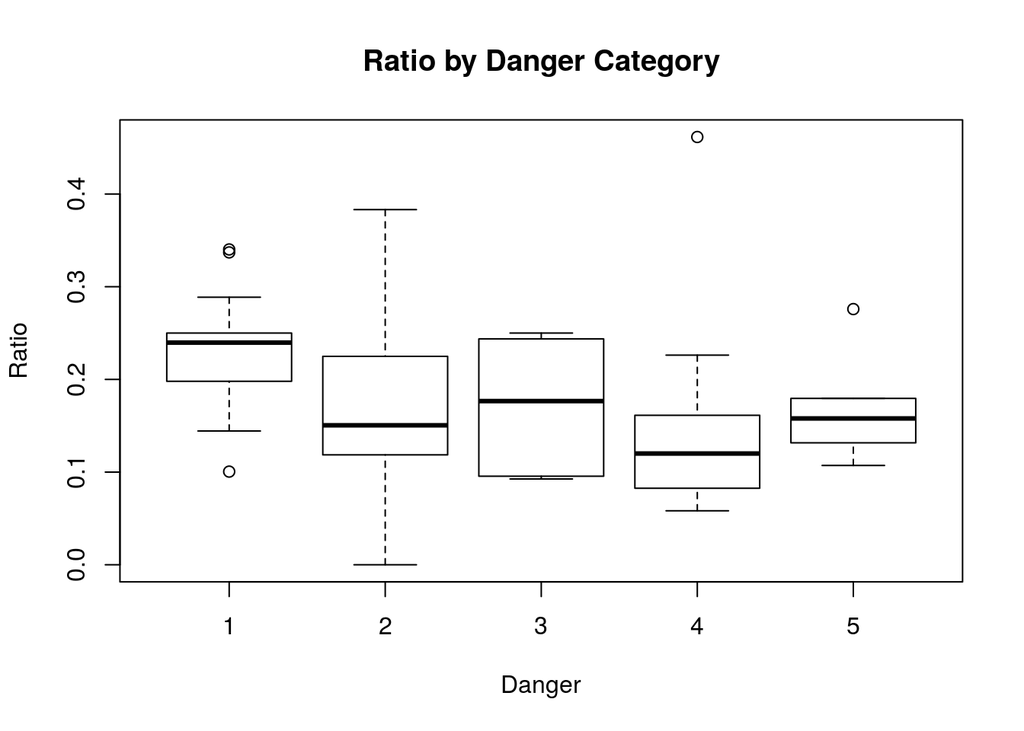

*Tip*: The function `with` can shorten the code significantly for expressions involving dataframes.

`with` creates an environment from the data, so that when you refer to the variables in the dataset, you no longer have refer to the dataset by name.

For example instead of writing

```r
# plot(really_long_dataframe_name$really_long_variable_name_1,
#       really_long_dataframe_name$really_long_variable_name2)
```

you can write

```r
# with(really_long_dataframe_name,
#     plot(really_long_variable_name_1,really_long_variable_name2))
```

See more on `?with`.

## Order the dataset by a variable

What if we want to reorder the dataframe accoring to the variable “Ratio”, in increasing order?

```
##    BodyWgt BrainWgt NonD Dream Sleep Span Gest Pred Exp Danger      Ratio
## 16   3.000    25.00  8.6   0.0   8.6 50.0   28    2   2      2 0.00000000
## 60   4.190    58.00  9.7   0.6  10.3 24.0  210    4   3      4 0.05825243
## 6   10.550   179.50  9.1   0.7   9.8 27.0  180    4   4      4 0.07142857
## 43  10.000   115.00 10.0   0.9  10.9 20.2  170    4   4      4 0.08256881
## 52   3.600    21.00  4.9   0.5   5.4  6.0  225    3   2      3 0.09259259
## 58   2.000    12.30  4.9   0.5   5.4  7.5  200    3   1      3 0.09259259
## 28   1.040     5.50  7.4   0.8   8.2  7.6   68    5   3      4 0.09756098
## 37   0.023     0.40 11.9   1.3  13.2  3.2   19    4   1      3 0.09848485
## 33   0.010     0.25 17.9   2.0  19.9 24.0   50    1   1      1 0.10050251
## 42   0.480    15.50 15.2   1.8  17.0 12.0  140    2   2      2 0.10588235
```

Hint: Does `sort` work? What about `order`?

## Q&A

What’s the difference between `|` (OR) and `||` (OR)?

A: `|` (OR) is bitwise operation. `||` (OR) is not.

```r
A <- c(F,T,F,T,F,T,T,F,T)
B <- c(F,F,T,F,T,F,F,T,F)
A|B
```

```
## [1] FALSE  TRUE  TRUE  TRUE  TRUE  TRUE  TRUE  TRUE  TRUE
```

```r
A||B
```

```
## [1] FALSE
```

Similarly for `&` (AND) and `&&` (AND).

.